# Practical Machine Learning Project

Week 04

### *Background*

The goal of your project is to predict the manner in which they did the exercise. This is the “classe” variable in the training set. You may use any of the other variables to predict with. You should create a report describing how you built your model, how you used cross validation, what you think the expected out of sample error is, and why you made the choices you did. You will also use your prediction model to predict 20 different test cases.

### *Libraries to be used*

```r
library(ggplot2)
library(caret)
library(randomForest)
library(rpart)
library(rpart.plot)
library(corrplot)
library(dplyr)
```

### *Acquiring the datasets*

```r
pmltraining_url <- "https://d396qusza40orc.cloudfront.net/predmachlearn/pml-training.csv"
pmltesting_url <-"https://d396qusza40orc.cloudfront.net/predmachlearn/pml-testing.csv"

download.file(pmltraining_url, "pml-training.csv", method = "curl")
```

```
  % Total    % Received % Xferd  Average Speed   Time    Time     Time  Current
                                 Dload  Upload   Total   Spent    Left  Speed

  0     0    0     0    0     0      0      0 --:--:-- --:--:-- --:--:--     0
  0     0    0     0    0     0      0      0 --:--:-- --:--:-- --:--:--     0
100 11.6M  100 11.6M    0     0  11.6M      0  0:00:01  0:00:01 --:--:-- 11.4M
```

```r
download.file(pmltesting_url, "pml-testing.csv", method = "curl")
```

```
  % Total    % Received % Xferd  Average Speed   Time    Time     Time  Current
                                 Dload  Upload   Total   Spent    Left  Speed

  0     0    0     0    0     0      0      0 --:--:-- --:--:-- --:--:--     0
  0 15113    0     0    0     0      0      0 --:--:-- --:--:-- --:--:--     0
100 15113  100 15113    0     0  15113      0  0:00:01 --:--:--  0:00:01 32292
```

### *Loading the datasets*

Loading datasets to “train” and “test” variables and identify “NA” and “#DIV/0!”

```r
trainRaw <- read.csv("pml-training.csv", na.strings = c("NA", "#DIV/0!", ""))
testRaw <- read.csv("pml-testing.csv", na.strings = c("NA", "#DIV/0!", ""))
```

Viewing the new dataset structure and dimensions

```r
#str(trainRaw)
#str(testRaw)

dim(trainRaw)
```

```
[1] 19622   160
```

```r
dim(testRaw)
```

```
[1]  20 160
```

The dim show us that the raw train data contains 19622 observations and 160 variables. It also shows that the test raw data contains 20 observations and 160 variables.

Converting trainRaw$classe to factor. This is done to avoid the error during model accuracy, because variable data ‘classe’ needs to be factor.

```r
trainRaw$classe <- as.factor(trainRaw$classe)
```

Viewing the variable classe before cleaning the datasets.

```r
table(trainRaw$classe)
```

```
   A    B    C    D    E
5580 3797 3422 3216 3607
```

### *Datasets cleaning*

Removing the first seven columns as they don’t have useful data.

```r
trainLessCol <- trainRaw[,-seq(1:7)]
testLessCol <- testRaw[,-seq(1:7)]
```

Removing columns with NAs on both train and test datasets.

```r
trainCleanData <- trainLessCol[,colSums(is.na(trainLessCol)) == 0]
testCleanData <- testLessCol[,colSums(is.na(testLessCol)) == 0]
```

### Dataset partitions

The already processed and clean train dataset will be split into two datasets. *1.-* into 70% for pure training. *2.-* into 30% for validation.

```r
set.seed(101)      # For reproducibility purpose

inTrain <- createDataPartition(trainCleanData$classe, p=0.70, list=F)
trainData <- trainCleanData[inTrain, ]
validationData <- trainCleanData[-inTrain, ]
```

Viewing the new datasets dimensions.

```r
# Dimension for the trainData
dim(trainData)
```

```
[1] 13737    53
```

```r
# Dimension for the validationData
dim(validationData)
```

```
[1] 5885   53
```

Checking to see if there are too many variable that could be correlated with corrplot.

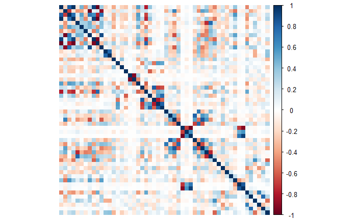

```r
corr_train_data <- select_if(trainCleanData, is.numeric)
corrplot(
    cor(corr_train_data),
    method = "color",
    tl.pos = "n",
    insig = "blank"
)
```

The graphs does show that there are some variable that are correlated, however, I don’t think it will affect too much the model

### Data Modeling

##### *Decision Tree*

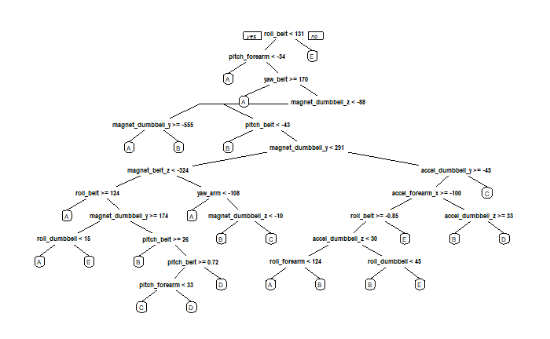

```r
modelDT <- rpart(classe ~ ., data=trainData, method="class")
# Plot the Decision Tree
prp(modelDT)
```

Prediction and Confusion Matrix for Decision Tree Model.

```r
predictDT <- predict(modelDT, validationData, type = "class")
# Test results on our validationData data set:
confusionMatrix(predictDT, validationData$classe)
```

```
Confusion Matrix and Statistics

          Reference
Prediction    A    B    C    D    E
         A 1485  256   50   72   70
         B   63  710  144   87  108
         C    8   49  743  148   68
         D  110   75   48  570   46
         E    8   49   41   87  790

Overall Statistics

               Accuracy : 0.7303
                 95% CI : (0.7188, 0.7416)
    No Information Rate : 0.2845
    P-Value [Acc > NIR] : < 2.2e-16

                  Kappa : 0.6568

 Mcnemar's Test P-Value : < 2.2e-16

Statistics by Class:

                     Class: A Class: B Class: C Class: D Class: E
Sensitivity            0.8871   0.6234   0.7242  0.59129   0.7301
Specificity            0.8936   0.9153   0.9438  0.94330   0.9615
Pos Pred Value         0.7682   0.6385   0.7313  0.67138   0.8103
Neg Pred Value         0.9522   0.9101   0.9419  0.92176   0.9405
Prevalence             0.2845   0.1935   0.1743  0.16381   0.1839
Detection Rate         0.2523   0.1206   0.1263  0.09686   0.1342
Detection Prevalence   0.3285   0.1890   0.1726  0.14427   0.1657
Balanced Accuracy      0.8904   0.7693   0.8340  0.76730   0.8458
```

Checking for the accuracy of the Decision Tree model.

```r
modelAccuracy <- postResample(predictDT, validationData$classe)
modelAccuracy
```

```
 Accuracy     Kappa
0.7303314 0.6568256
```

```r
accuracyDT <- 1 - as.numeric(confusionMatrix(validationData$classe, predictDT)$overall[1])
accuracyDT
```

```
[1] 0.2696686
```

The Decision Tree model accurate is 73.03% and the estimated out-of-sample error is 26.96%.

##### *Gradient Boosted Model*

```r
modelGbm <- train(classe~., method="gbm", data=trainData, verbose=FALSE)
```

```r
predictGbm <- predict(modelGbm, validationData)
confusionMatrix(validationData$classe, predictGbm)
```

```
Confusion Matrix and Statistics

          Reference
Prediction    A    B    C    D    E
         A 1650   16    5    2    1
         B   29 1079   30    1    0
         C    0   35  979   10    2
         D    1    4   36  908   15
         E    1   11   11    7 1052

Overall Statistics

               Accuracy : 0.9631
                 95% CI : (0.958, 0.9678)
    No Information Rate : 0.2856
    P-Value [Acc > NIR] : < 2.2e-16

                  Kappa : 0.9533

 Mcnemar's Test P-Value : 1.37e-06

Statistics by Class:

                     Class: A Class: B Class: C Class: D Class: E
Sensitivity            0.9816   0.9424   0.9227   0.9784   0.9832
Specificity            0.9943   0.9873   0.9903   0.9887   0.9938
Pos Pred Value         0.9857   0.9473   0.9542   0.9419   0.9723
Neg Pred Value         0.9926   0.9861   0.9831   0.9959   0.9963
Prevalence             0.2856   0.1946   0.1803   0.1577   0.1818
Detection Rate         0.2804   0.1833   0.1664   0.1543   0.1788
Detection Prevalence   0.2845   0.1935   0.1743   0.1638   0.1839
Balanced Accuracy      0.9879   0.9648   0.9565   0.9836   0.9885
```

Checking for the accuracy of the Gradient Boosted model.

```r
modelAccuracy <- postResample(predictGbm, validationData$classe)
modelAccuracy
```

```
 Accuracy     Kappa
0.9631266 0.9533485
```

```r
accuracyGbm <- 1 - as.numeric(confusionMatrix(validationData$classe, predictGbm)$overall[1])
accuracyGbm
```

```
[1] 0.03687341
```

The Gradient Boosted model accurate is 96.31% and the estimated out-of-sample error is 3.68%.

###### *Random Forest*

```r
controlRf <- trainControl(method="cv", 5)
modelRf <- train(classe ~ ., data=trainData, method="rf", trControl=controlRf, ntree=250)
modelRf
```

```
Random Forest

13737 samples
   52 predictor
    5 classes: 'A', 'B', 'C', 'D', 'E'

No pre-processing
Resampling: Cross-Validated (5 fold)
Summary of sample sizes: 10989, 10989, 10991, 10990, 10989
Resampling results across tuning parameters:

  mtry  Accuracy   Kappa
   2    0.9895903  0.9868319
  27    0.9900998  0.9874765
  52    0.9871880  0.9837925

Accuracy was used to select the optimal model using the largest value.
The final value used for the model was mtry = 27.
```

```r
predictRf <- predict(modelRf, validationData)
confusionMatrix(validationData$classe, predictRf)
```

```
Confusion Matrix and Statistics

          Reference
Prediction    A    B    C    D    E
         A 1672    1    0    0    1
         B   10 1126    3    0    0
         C    0    0 1026    0    0
         D    0    1    9  953    1
         E    0    0    3    3 1076

Overall Statistics

               Accuracy : 0.9946
                 95% CI : (0.9923, 0.9963)
    No Information Rate : 0.2858
    P-Value [Acc > NIR] : < 2.2e-16

                  Kappa : 0.9931

 Mcnemar's Test P-Value : NA

Statistics by Class:

                     Class: A Class: B Class: C Class: D Class: E
Sensitivity            0.9941   0.9982   0.9856   0.9969   0.9981
Specificity            0.9995   0.9973   1.0000   0.9978   0.9988
Pos Pred Value         0.9988   0.9886   1.0000   0.9886   0.9945
Neg Pred Value         0.9976   0.9996   0.9969   0.9994   0.9996
Prevalence             0.2858   0.1917   0.1769   0.1624   0.1832
Detection Rate         0.2841   0.1913   0.1743   0.1619   0.1828
Detection Prevalence   0.2845   0.1935   0.1743   0.1638   0.1839
Balanced Accuracy      0.9968   0.9977   0.9928   0.9973   0.9984
```

Checking for the accuracy of the Random Forest model.

```r
modelAccuracy <- postResample(predictRf, validationData$classe)
modelAccuracy
```

```
 Accuracy     Kappa
0.9945624 0.9931212
```

```r
accuracyRF <- 1 - as.numeric(confusionMatrix(validationData$classe, predictRf)$overall[1])
accuracyRF
```

```
[1] 0.005437553
```

The Random Forest model accurate is 99.45% and the estimated out-of-sample error is 0.54%.

#### Which Prediction Model was better

```r
accuracyAll <- rbind(confusionMatrix(predictDT, validationData$classe)$overall["Accuracy"],
confusionMatrix(predictGbm, validationData$classe)$overall["Accuracy"],
confusionMatrix(predictRf, validationData$classe)$overall["Accuracy"])
row.names(accuracyAll) <- c("DT", "Gbm", "RF")

accuracyAll
```

```
     Accuracy
DT  0.7303314
Gbm 0.9631266
RF  0.9945624
```

We can see the the better model from the three that we have tested is Random Forest Model, however, Gradient Boosted Model could be a second choice.

```r
predictfinal <- predict(modelRf, testCleanData[, -length(names(testCleanData))])
predictfinal
```

```
 [1] B A B A A E D B A A B C B A E E A B B B
Levels: A B C D E
```